# Selina Narain DTSC 630 Homework 1

2023-02-06

## Question 1

**The first ten days of rainfall amounts in NYC in 1996 are as follows: 0.1, 0.6, 33.8, 1.9, 9.6, 4.3, 33.7, 0.3, 0.0, 0.1**

**Read the above into a vector.**

```r
rainfallAmount <- c(0.1, 0.6, 33.8, 1.9, 9.6, 4.3, 33.7, 0.3, 0.0, 0.1)
print(rainfallAmount)
```

```
##  [1]  0.1  0.6 33.8  1.9  9.6  4.3 33.7  0.3  0.0  0.1
```

**Calculate the mean and standard deviation of the rainfall amounts.**

```r
mean(rainfallAmount)
```

```
## [1] 8.44
```

```r
sd(rainfallAmount)
```

```
## [1] 13.66473
```

**Display the cumulative rainfall (“running total”) over the ten days (0.1, 0.7, 34.5, 36.4, ….)**

```r
cumsum(rainfallAmount)
```

```
##  [1]  0.1  0.7 34.5 36.4 46.0 50.3 84.0 84.3 84.3 84.4
```

**Find out the day when the rainfall was the highest, and day when it was the lowest.**

```r
which.max(rainfallAmount)
```

```
## [1] 3
```

```r
which.min(rainfallAmount)
```

```
## [1] 9
```

## Question 2

**Draw 20 random letters from the upper case alphabet, and sort them alphabetically.**

```r
LETTERS
```

```
##  [1] "A" "B" "C" "D" "E" "F" "G" "H" "I" "J" "K" "L" "M" "N" "O" "P" "Q" "R" "S"
## [20] "T" "U" "V" "W" "X" "Y" "Z"
```

```r
uppercaseAlphabet <- sample(LETTERS, 20)
print(uppercaseAlphabet)
```

```
##  [1] "B" "E" "S" "F" "V" "P" "A" "R" "I" "H" "D" "Z" "X" "J" "Y" "U" "K" "G" "N"
## [20] "C"
```

```r
sort(uppercaseAlphabet)
```

```
##  [1] "A" "B" "C" "D" "E" "F" "G" "H" "I" "J" "K" "N" "P" "R" "S" "U" "V" "X" "Y"
## [20] "Z"
```

## Question 3

**This exercise is about matrix, column means, histogram.**

**Construct a matrix with 10 columns and 10 rows with elements generated from uniform random numbers between 0 and 1.**

```r
matrixNumbers = runif(10*10)
A <- matrix(matrixNumbers, 10, 10)
print(A)
```

```
##             [,1]       [,2]       [,3]       [,4]       [,5]       [,6]
##  [1,] 0.88687318 0.89790009 0.40763313 0.42330204 0.49399069 0.02901035
##  [2,] 0.69447328 0.05648946 0.11973827 0.88828227 0.23518338 0.35561575
##  [3,] 0.90768955 0.56839889 0.06705066 0.19272493 0.07918383 0.17116591
##  [4,] 0.44518354 0.32173877 0.51997675 0.81946482 0.81234150 0.36562312
##  [5,] 0.31410933 0.63332520 0.35143916 0.86915125 0.61506032 0.89402940
##  [6,] 0.87291457 0.71463532 0.61260954 0.71520630 0.37728774 0.98608329
##  [7,] 0.63798411 0.93314655 0.70517099 0.97915129 0.65374196 0.01035611
##  [8,] 0.34445079 0.46047167 0.21106605 0.45770807 0.24941976 0.52583208
##  [9,] 0.07185172 0.02258500 0.70428084 0.06558385 0.73762236 0.74675098
## [10,] 0.80838087 0.95777865 0.55804691 0.15324373 0.22910304 0.87624771
##             [,7]      [,8]       [,9]      [,10]
##  [1,] 0.98552282 0.1587339 0.29750763 0.35556647
##  [2,] 0.29172697 0.2622342 0.14937079 0.62277641
##  [3,] 0.07819567 0.7251914 0.97986480 0.28356043
##  [4,] 0.80269231 0.7118749 0.75862753 0.53959372
##  [5,] 0.61654259 0.5423432 0.09182783 0.01913503
##  [6,] 0.76847380 0.1280415 0.73536016 0.90586571
##  [7,] 0.89696641 0.7935539 0.62117636 0.85621121
##  [8,] 0.95373366 0.1107655 0.33359430 0.90827307
##  [9,] 0.96447483 0.2439650 0.93525339 0.56911189
## [10,] 0.14202024 0.6434334 0.65317302 0.43184296
```

**Calculate the 10 column means of the matrix, and the standard deviation of them.**

```r
colMeans(A)
```

```
##  [1] 0.5983911 0.5566470 0.4257012 0.5563819 0.4482935 0.4960715 0.6500349
##  [8] 0.4320137 0.5555756 0.5491937
```

```r
sd(colMeans(A))
```

```
## [1] 0.07432697
```

**Now generate a matrix with 100 columns and 10 rows. Then calculate the 100 column means and plot a frequent diagram (or histogram).**

```r
matrixNumbers = runif(100*10)
B <- matrix(matrixNumbers, 10, 100)
print(B)
```

```
##              [,1]       [,2]      [,3]      [,4]        [,5]      [,6]
##  [1,] 0.979073226 0.74662974 0.5421948 0.2085193 0.006952156 0.7207664
##  [2,] 0.472622573 0.87052438 0.9597533 0.1806674 0.425940201 0.5798920
##  [3,] 0.155001604 0.66299690 0.4424946 0.4343732 0.806320957 0.3333941
##  [4,] 0.320446118 0.02674381 0.9906978 0.7626381 0.844134644 0.8904236
##  [5,] 0.694006817 0.93843172 0.2717736 0.3124008 0.201316467 0.1370037
##  [6,] 0.059169549 0.95125458 0.2164036 0.9667088 0.514763052 0.2879566
##  [7,] 0.584816291 0.82934048 0.1487044 0.8858473 0.027683283 0.1372102
##  [8,] 0.767892241 0.55120089 0.9541110 0.5509175 0.279321102 0.7074344
##  [9,] 0.004684106 0.70270818 0.7508682 0.1456040 0.421875260 0.1128459
## [10,] 0.225210638 0.35622462 0.2019671 0.6344383 0.553939005 0.8541635
##              [,7]       [,8]       [,9]     [,10]     [,11]     [,12]     [,13]
##  [1,] 0.437952638 0.35451686 0.70869915 0.1822513 0.6258201 0.3726334 0.9417014
##  [2,] 0.613995854 0.50891547 0.14175311 0.5802505 0.4306105 0.3381299 0.3879809
##  [3,] 0.817171199 0.41338050 0.09189753 0.9444998 0.5681234 0.4800035 0.1307147
```

[output cut: 161 more lines]

```r
mColB <- colMeans(B)
print(mColB)
```

```
##   [1] 0.4262923 0.6636055 0.5478968 0.5082115 0.4082246 0.4761090 0.5581400
##   [8] 0.3074103 0.5648776 0.6481868 0.5493868 0.5842876 0.4486480 0.4648438
##  [15] 0.4498623 0.4569700 0.7170383 0.5282698 0.3927117 0.5387764 0.2885326
##  [22] 0.5363614 0.5721926 0.6203138 0.5837822 0.4058879 0.5402395 0.4640485
##  [29] 0.5028980 0.5351202 0.4019326 0.5191454 0.4310813 0.4425391 0.5500622
##  [36] 0.5320821 0.5271321 0.3543008 0.4862110 0.7016258 0.5400342 0.4568281
##  [43] 0.4287175 0.4337699 0.4998415 0.4786905 0.5486522 0.4715779 0.6005427
##  [50] 0.5838951 0.4252725 0.4750612 0.5179028 0.5100681 0.3983315 0.3519994
##  [57] 0.5376681 0.4226058 0.5662387 0.5698913 0.5685934 0.6453626 0.5564886
##  [64] 0.4477164 0.2844728 0.3579228 0.5964320 0.5998813 0.5663935 0.6556242
##  [71] 0.5167984 0.4425956 0.5209700 0.3826723 0.4536892 0.4699684 0.3125790
##  [78] 0.3912633 0.5288509 0.6547762 0.5729295 0.4546495 0.6401766 0.5673177
##  [85] 0.4342415 0.5596756 0.5807298 0.3469847 0.5374638 0.4325244 0.5717535
##  [92] 0.6973801 0.7617588 0.5453679 0.5325179 0.4308978 0.4327085 0.4417432
##  [99] 0.4564239 0.4032646
```

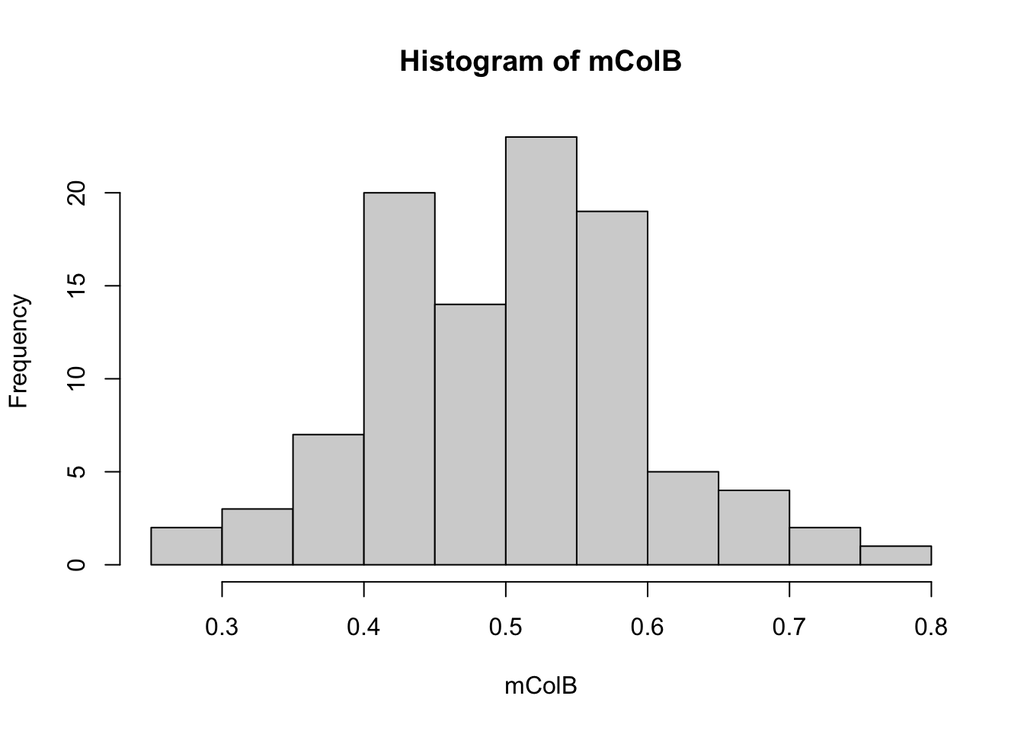

```r
hist(mColB)
```

**What shape of the histogram do you expect? Experiment the above with another matrix of 1000 columns and 10 rows.**

The expected shape of the histogram would be a bell curve which would represent a normal distribution.

```r
matrixNumbers = runif(1000*10)
C <- matrix(matrixNumbers, 10, 1000)
print(C)
```

```
##             [,1]      [,2]       [,3]       [,4]      [,5]      [,6]       [,7]
##  [1,] 0.69018820 0.5256782 0.39308988 0.41011465 0.6635581 0.4432791 0.11411560
##  [2,] 0.06593264 0.5160167 0.48657765 0.16775284 0.3609850 0.3206664 0.25903649
##  [3,] 0.26026267 0.3574331 0.08979945 0.88487940 0.1146700 0.5774102 0.28061091
##  [4,] 0.22142994 0.1056010 0.86003943 0.81746372 0.5931960 0.9734135 0.37006278
##  [5,] 0.90326126 0.1858573 0.66826708 0.42177398 0.1964628 0.7938576 0.43879404
##  [6,] 0.85865212 0.5118483 0.87640625 0.09310969 0.4241995 0.2652526 0.54107526
##  [7,] 0.75352961 0.4763320 0.32677834 0.10659529 0.4057327 0.2203788 0.06488709
##  [8,] 0.57724568 0.3083917 0.86155861 0.41417033 0.2825704 0.2025275 0.28067450
##  [9,] 0.70980455 0.2866476 0.72422598 0.36442203 0.9241504 0.5868305 0.05980459
## [10,] 0.71520572 0.3304698 0.22050858 0.31132700 0.8837574 0.8514680 0.85416994
##             [,8]       [,9]       [,10]     [,11]     [,12]      [,13]
##  [1,] 0.03285301 0.84100008 0.008951438 0.9063212 0.7451501 0.12732975
##  [2,] 0.75110612 0.08543274 0.112828275 0.7273342 0.8808521 0.77282510
##  [3,] 0.95267349 0.32365213 0.084510955 0.4325544 0.8048665 0.01680785
```

[output cut: 1723 more lines]

```r
mColC <- colMeans(C)
print(mColC)
```

```
##    [1] 0.5755512 0.3604276 0.5507251 0.3991609 0.4849282 0.5235084 0.3263231
##    [8] 0.4204700 0.3654765 0.4002809 0.6086106 0.8015735 0.2651015 0.4831435
##   [15] 0.5743680 0.5216054 0.3618852 0.5678020 0.6700437 0.3883793 0.4066608
##   [22] 0.5650949 0.5687046 0.5197905 0.6501137 0.6977276 0.5089951 0.4099465
##   [29] 0.3560287 0.5719894 0.5483161 0.5292215 0.5096526 0.4163480 0.5175524
##   [36] 0.3967503 0.5732807 0.5226694 0.5638660 0.5620640 0.4081604 0.5231695
##   [43] 0.4515036 0.3168005 0.4407860 0.3808969 0.5000846 0.5234624 0.5292692
##   [50] 0.4409973 0.5253911 0.5147881 0.4536995 0.3741041 0.6082064 0.6249926
##   [57] 0.4569198 0.5171349 0.3682225 0.4053111 0.6633898 0.4819264 0.3972880
##   [64] 0.4878065 0.2506745 0.6087742 0.5056970 0.4630750 0.4028676 0.7311817
##   [71] 0.5271420 0.4597961 0.4111136 0.5318906 0.5736184 0.3940195 0.5425411
##   [78] 0.5019178 0.5580312 0.3034629 0.5773810 0.4287103 0.2977564 0.5727499
##   [85] 0.4286465 0.2580184 0.5040952 0.6231619 0.3326235 0.5480625 0.5618231
##   [92] 0.6560581 0.6055252 0.4843095 0.5464803 0.4885050 0.3102366 0.5112326
##   [99] 0.5086722 0.5169386 0.5813354 0.4829929 0.4086873 0.5208804 0.4121885
```

[output cut: 128 more lines]

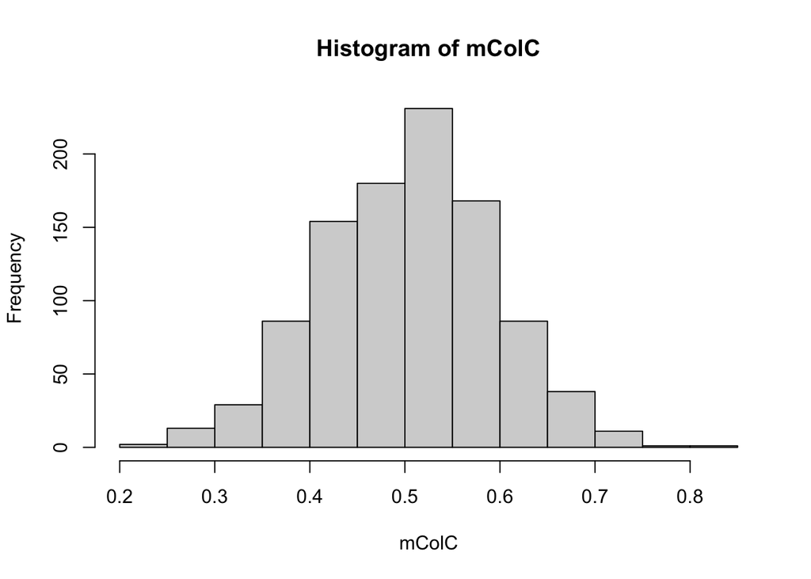

```r
hist(mColC)
```

## Question 4

**Read the rainfall data from Problem 1 into a vector.**

**Produce a subset of the data where rain is larger than 20.**

```r
R <- rainfallAmount
R[R > 20]
```

```
## [1] 33.8 33.7
```

**What is the mean rainfall for days where the rainfall was at least 4?**

```r
S <- R[R >= 4]
mean(S)
```

```
## [1] 20.35
```

**Produce a subset where the rainfall is either exactly 0, or exactly 0.6.**

```r
T <- R[R == 0 | R == 0.6]
print(T)
```

```
## [1] 0.6 0.0
```